# Reproducible Research: Peer Assessment 1

## Loading and processing the Data

- Loading the data from the downloaded csv file

```r
activity <- read.csv("~/Coursera/activity.csv", colClasses = c("numeric", "Date", "numeric"))
attach(activity)
```

- Loading the required packages

```r
library(knitr)
library(lubridate)
library(lattice)
library (ggplot2)
library (reshape2)
library(plyr)
library(dplyr)
```

- Process the data into a format suitable for analysis

```r
activity$date <- ymd(activity$date)
```

## 1. What is the mean total number of steps taken per day?

### For this part of the assignment, you can ignore the missing values in the dataset.

- Calculate the total number of steps taken per day

```r
steps_taken <- aggregate(steps ~ date, activity, sum)
```

### If you do not understand the difference between a histogram and a barplot, research the difference between them.

- Make a histogram of the total number of steps taken each day.

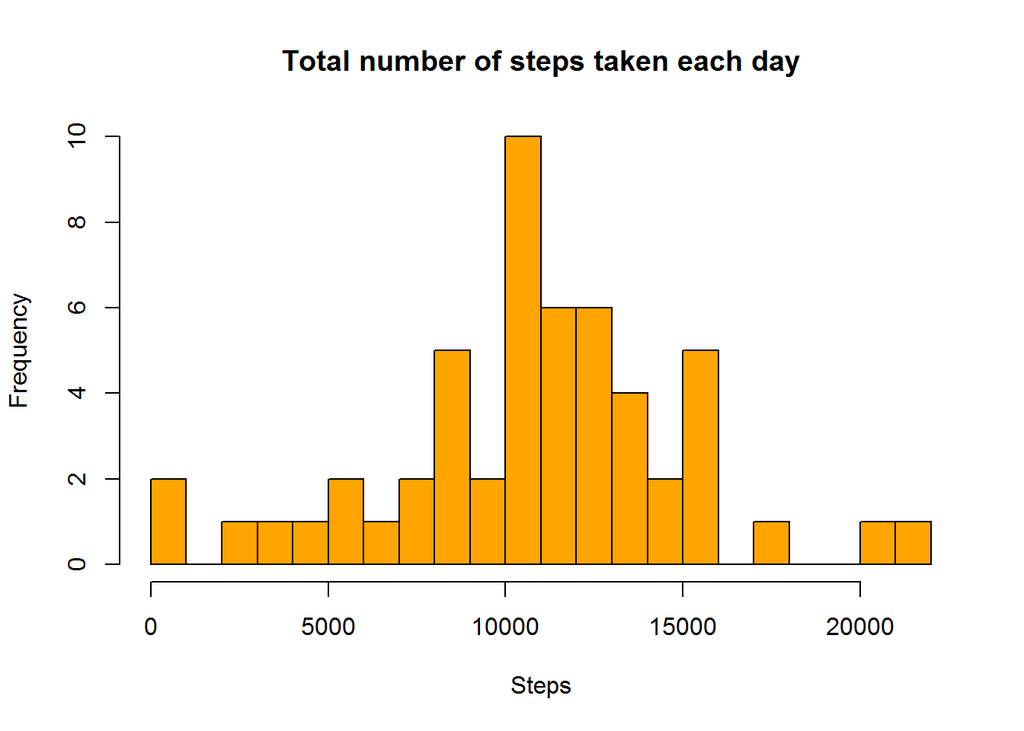

```r
hist(steps_taken$steps, breaks = 25, main = "Total number of steps taken each day", xlab = "Steps", col = "orange")
```

- Calculate and report the mean and median of the total number of steps taken per day

```r
stepmean <- mean(steps_taken$steps)
stepmedian <- median(steps_taken$steps)
```

- Mean

```r
stepmean
```

```
## [1] 10766.19
```

- Median

```r
stepmedian
```

```
## [1] 10765
```

## 2. What is the average daily activity pattern?

- Make a time series plot (i.e. type = “l”) of the 5-minute interval (x-axis) and the average number of steps taken, averaged across all days (y-axis)

```r
daily <- tapply(activity$steps, activity$interval, mean, na.rm = TRUE)
dailymelt <- melt (daily)
names(dailymelt) <- c("interval", "avg")
nrow (dailymelt)
```

```
## [1] 288
```

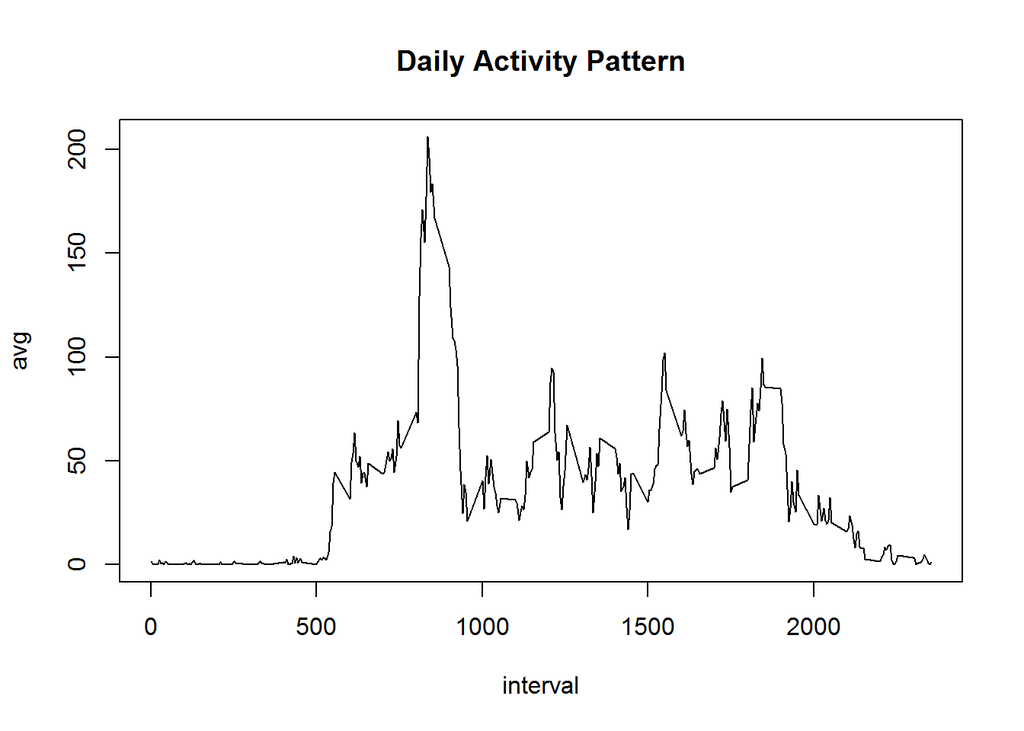

```r
plot(avg ~ interval, data = dailymelt, type = "l", main = "Daily Activity Pattern")
```

- Which 5-minute interval, on average across all the days in the dataset, contains the maximum number of steps?

```r
dailymelt[dailymelt$avg == max(dailymelt$avg), ]
```

```
##     interval      avg
## 104      835 206.1698
```

## 3. Imputing missing values

### Note that there are a number of days/intervals where there are missing values (coded as NA). The presence of missing days may introduce bias into some calculations or summaries of the data.

- Calculate and report the total number of missing values in the dataset (i.e. the total number of rows with NAs)

```r
sum (is.na (activity))
```

```
## [1] 2304
```

### Devise a strategy for filling in all of the missing values in the dataset. The strategy does not need to be sophisticated. For example, you could use the mean/median for that day, or the mean for that 5-minute interval, etc.

- Create a new dataset that is equal to the original dataset but with the missing data filled in.

```r
mean(activity$steps, na.rm = TRUE)

merged_NAs <- activity
merged_NAs$steps [is.na(merged_NAs$steps)] <- mean(merged_NAs$steps, na.rm = TRUE)
colSums(is.na(merged_NAs))
```

[output not shown]

```r
merged_NAs <- tapply(merged_NAs$steps, merged_NAs$date, sum)
melted <- melt(merged_NAs)
names(melted) <- c("Date", "Steps_taken")
```

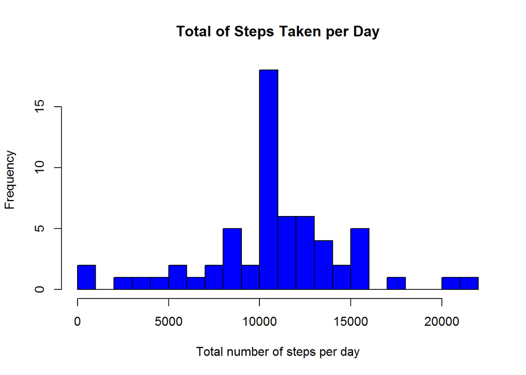

```r
hist(melted$Steps_taken, main = "Total of Steps Taken per Day", xlab = "Total number of steps per day",
     ylab = "Frequency", col = "blue", breaks = 25)
```

## 4 Are there differences in activity patterns between weekdays and weekends?

### For this part the weekdays() function may be of some help here. Use the dataset with the filled-in missing values for this part.

- Create a new factor variable in the dataset with two levels - “weekday” and “weekend” indicating whether a given date is a weekday or weekend day.

```r
merged_NAs <- activity
merged_NAs$steps [is.na(merged_NAs$steps)] <- mean(merged_NAs$steps, na.rm = TRUE)
colSums(is.na(merged_NAs))
```

```
##    steps     date interval
##        0        0        0
```

```r
merged_NAs$weekdays <- weekdays(merged_NAs$date)
merged_NAs$weeks[(merged_NAs$weekdays == "Saturday" | merged_NAs$weekdays == "Sunday")] <- "weekend"
merged_NAs$weeks[!(merged_NAs$weekdays == "Saturday" | merged_NAs$weekdays == "Sunday")] <- "weekdays"

weeks_ <- ddply(merged_NAs, c("interval", "weeks"), function (x) apply(x[1], 2, mean))
```

- Make a panel plot containing a time series plot (i.e. type = “l”) of the 5-minute interval (x-axis) and the average number of steps taken, averaged across all weekday days or weekend days (y-axis). See the README file in the GitHub repository to see an example of what this plot should look like using simulated data.

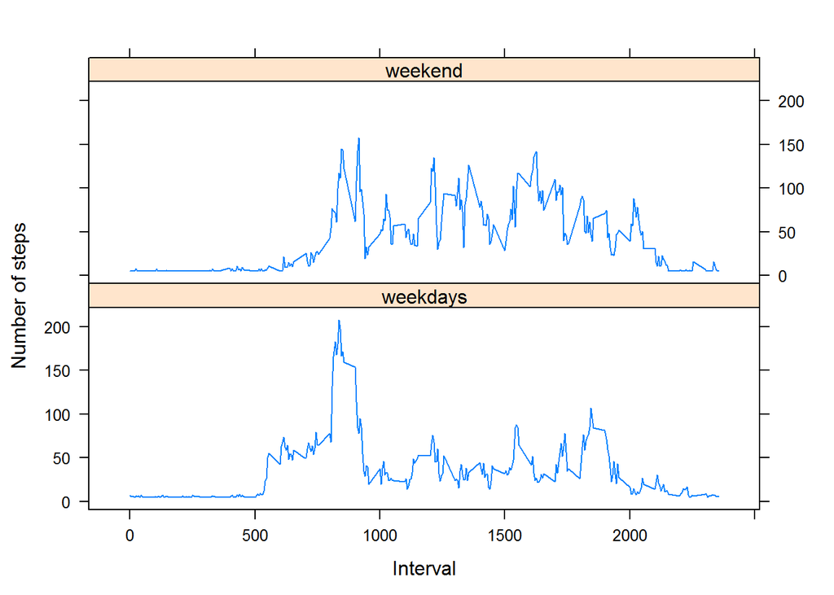

```r
xyplot(steps ~ interval | weeks, data = weeks_, type = "l", xlab = "Interval",
       ylab = "Number of steps", layout = c(1, 2))
```